# Hackathon Report: Opinions on Extramarital Sex

Created for Prof. Deirdre Bloome, SOC 210, Winter 2020

Conrad Diao, Quantae Carr, Samantha Post

04/15/2020

### Hackathon Report, Section 1: Introduction

In the United States, as of 2019, extramarital sex is a criminal offense in 19 states. Though prosecutions are rare, the legal consequences of extramarital sex, often called adultery, can be severe: in Michigan, the maximum statute is 4 years in prison. Beyond the legal implications, the social stigma around extramarital sex is immense, too. Additionally, the high proportion of marriages in the U.S. which end in divorce is well-publicized, and many believe that extramarital sex is a leading cause. Marriage is a defining part of the national identity, and as such, it is interesting to ask: *How have U.S. adults’ opinions on extramarital sex changed over time, between 1973 and 2018?*. We might begin to understand how marriage outcomes affect sentiment toward Extramarital sex, too, by asking: *How have U.S. adults’ opinions on extramarital sex differed by marital status since 1973?*. And finally, we might begin to question how different attitudinal/financial groups (a deeply seated aspect of the American identity and set of ideals) think about Extramarital sex by asking: *How have U.S. adults’ opinions on extramarital sex differed by their opinion of their family income relative to that of the “average” American family since 1973?*

To reiterate, this study aims to build an understanding of the relationship between sentiment toward extramarital sex and two demographic and attitudinal characteristics: marital status and opinion of family income.

1. How have U.S. adults’ opinions on extramarital sex changed over time, between 1973 and 2018?
2. How have U.S. adults’ opinions on extramarital sex differed by marital status since 1973?
3. How have U.S. adults’ opinions on extramarital sex differed by their opinion of their family income relative to that of the “average” American family since 1973?

### Hackathon Report, Section 2: Data and Measures

**Dataset Description**

We will be taking a look at data from the General Social Survey (GSS), which encompasses representative samples of adults over the age of 18, who speak English or Spanish and live within the United States. The data includes both their demographics and psychographics (attitudes and behaviors), spanning from 1972 to 2018. Our analysis will only account for valid responses to each of the questions posed in the survey, excluding response choices of “don’t know”, “no answer”, and “not applicable”. Below is a table of the variables, the question wording associated with them, and the possible responses.

| Name | Description | Question | Responses | Recoded Responses |
| --- | --- | --- | --- | --- |
| `year` | Year survey conducted | N/A | 1972 - 2018 |  |
| `xmarsex` | Opinion on married individuals having sexual relations with someone other than their marriage partner | What is your opinion about a married person having sexual relations with someone other than the marriage partner–is it always wrong, almost always wrong, wrong only sometimes, or not wrong at all? | Always wrong, Almst always wrg, Sometimes wrong, Not wrong at all, Don’t know, No answer, Not applicable | Always wrong, Almst always wrg, Sometimes wrong, Not wrong at all, Not always wrong |
| `marital` | Marital status | Are you currently–married, widowed, divorced, separated, or have you never been married? | Married, Widowed, Divorced, Separated, Never married, No answer | Married or widowed, Divorced or separated, Never married |
| `finrela` | Opinion of family income compared to American families in general | Compared with American families in general, would you say your family income is far below average, below average, average, above average, or far above average? (PROBE: Just your best guess.) | Far below average, Below average, Average, Above average, Far above average, Don’t know, No answer, Not applicable | Below average, Average, Above average |

**Sample Size**

After removing unmeaningful observations from our data set, our sample size is 38,744.

**Variable and Response Choice Description**

We analyzed 4 variables in the data set: opinion on extramarital sex, year, marital status, and opinion on family income. We used the variable called `year` from the GSS which originally captured the year in which the survey was given to a participant, ranging from 1973 to 2018.

To understand differences in opinions about extramarital sex, we use the categorical variable called `xmarsex` from the GSS. `xmarsex` originally captured responses to the question *“What is your opinion about a married person having sexual relations with someone other than the marriage partner–is it always wrong, almost always wrong, wrong only sometimes, or not wrong at all?”* The proportions of the responses were, roughly, 0.76, 0.14, 0.08, 0.02 for those who reported their opinion of extramarital sex to be “always wrong,” “almost always wrong,” “sometimes wrong,” “not wrong at all,” respectively.

To understand differences in marital status, we use the categorical variable called `marital` from the GSS. `marital` originally captured responses to the question *“Are you currently–married, widowed, divorced, separated, or have you never been married?”* The proportions of the responses were, roughly, 0.13, 0.53, 0.21, 0.04, 0.10 for those who reported their marital status as “divorced,” “married,” “never married,” “separated,” and “widowed,” respectively.

To understand differences in opinion of family financial status, we use the categorical variable called `finrela` from the GSS. `finrela` originally captured responses to the question *“Compared with American families in general, would you say your family income is far below average, below average, average, above average, or far above average? (PROBE: Just your best guess.)”* The proportions of the responses, were, roughly, 0.06, 0.25, 0.50, 0.18, 0.02 for those who reported their perception of their own family income relative to American families in general as, “far below average,” “below average,” “average,” “above average,” and “far above average,” respectively.

**Refactor Explaination**

We will begin by reducing the complete dataset `gss.full` to one which only contains the variables that we are interested in, called `gss.small`, using the `select()` command. We will also filter out observations that do not contain meaningful information about our variables of interest. `marital` and `finrela` both have over 4 categories, so we collapse each, such that for `marital`, “Married” and “Widowed” are recoded into one category called “Married or widowed”, and “Divorced” and “Separated” are recoded into one category called “Divorced or separated”, and for `finrela`, “Far above average” and “Above average” are recoded into one category called “Above average” and “Far below average” and “Below average” are recoded into one category called “Below average”. To further refine our dataset, we ensure that for each of our categorical variables, `xmarsex`, `finrela`, and `marital`, each displays the response categories in order of sentiment, rather than alphabetically.

Additionally, for each category of our outcome variable `xmarsex` we create a dichotomous boolean variable (0, 1) and a new variable called `xmarsex.sometimes.wrong`, grouping all responses that are not “Always wrong” into one. This will help us in later statistical calculations.

We then created a new table that has one observation per `year-marital-finrela-xmarsex` combination and that captures the proportion of respondents in each group using the `group_by()`, `summarise()`, and `gather()` commands. This will allow us to see the different proportions of respondents across our variables. Lastly, we recoded the names of the proportions from “prop.always.wrong”, “prop.almost.always.wrong”, “prop.sometimes.wrong”, “prop.never.wrong”, “prop.maybe.wrong” to “Always wrong”, “Almost always wrong”, “Sometimes wrong”, “Never wrong”, and “Not always wrong”, respectively.

**Key Summary Statistics**

After refactoring, releveling, and collapsing, the proportions of the responses for the variables that we are investigating are as follows: `marital.collapsed`: “Married or widowed”, “Divorced or separated”, “Never married,” 0.62, 0.16, 0.21, respectively, and `finrela.collapsed`: “Below average”, “Average”, “Above average,” 0.30, 0.50, 0.20, respectively.

### Hackathon Report, Section 3: Hypothesis

**1) How have U.S. adults’ opinions on extramarital sex changed over time, between 1973 and 2018?**

Regarding our first research question, we hypothesize that the share of people who consider extramarital sex to be always wrong will decline between 1973 and 2018 because we observe, anecdotally, that American culture is increasingly liberal and alternative, and extramarital sex, in contrast to the monogamy which marriage calls for, is likewise non-traditional. However, we hypothesize that the change over time will be very small because the socialization of the importance of marital monogamy is very strong.

To answer this question and assess our hypothesis we will graph the proportion of respondents in each group of opinion of extramarital sex over time from 1973 to 2018. We will evaluate these proportions with 95% confidence intervals, which will be represented on our graph ‘Public Opinions on Extramarital Sex Over Time’ as ribbons around each response choice category’s trend line. We will also complete a hypothesis test to determine if the proportion of one response we are particularly concerned with, “Always wrong” changed between 1973 and 2018. We will also create confidence intervals for this difference in proportions (1973 versus 2018) to estimate how much change there was in the opinion that Extramarital sex is always wrong.

**2) How have U.S. adults’ opinions on extramarital sex differed by marital status since 1973?**

Regarding our second research question, we hypothesize that among U.S. adults who are married or widowed, a higher proportion, as compared to those who are divorced or separated, or those who have never married, will, on average, consider extramarital sex always wrong. We believe this to be true because extramarital sex is a cause for divorce or separation, and those who have never married may well be less supportive of the normative conditions of marriage regarding extramarital sex. We hypothesize that this difference will be moderate.

To answer this question and assess our hypothesis, we will graph the proportion of respondents who reported “always wrong” as their opinion on extramarital sex, our outcome variable, for each of our collapsed marital status categories. We will evaluate these proportions with 95% confidence intervals, which will be represented on our graph ‘Public Opinions on Extramarital Sex by Marital Status’ with error bars. We can then determine whether or not there are statistically significant differences, which will be evident on our graph by the presence, or lack thereof, of asterisks denoting the significant level.

**3) How have U.S. adults’ opinions on extramarital sex differed by their opinion of their family income relative to that of the “average” American family since 1973?**

Regarding our third research question, we hypothesize that among U.S. adults’ who believe that their family income is above average (including those who report far above average - see recoding explaination in Section 2), a lower proportion, as compared to those who consider their family income below average (including those who report far below average - see recoding explaination in Section 2), and those who consider their family income to be average will consider extramarital sex always wrong. We believe that this will be the case because respondents who perceive that they are of a higher income group may be socialized in a way that foregrounds independence rather than the cohesion to the family unit. We believe that this difference will be moderate.

To answer this question and assess this hypothesis, we will graph the proportion of respondents who reported “always wrong” as their opinion on extramarital sex, our outcome variable, for each of our collapsed family income categories. We will evaluate these proportions with 95% confidence intervals, which will be represented on our graph ‘Public Opinions on Extramarital Sex by Family Income’ with error bars. We can then determine whether or not there are statistically significant differences, which will be evident on our graph by the presence, or lack thereof, of asterisks denoting the significance level.

### Hackathon Report, Section 4: Results

**Research Question 1, How have U.S. adults’ opinions on extramarital sex changed over time, between 1973 and 2018?**

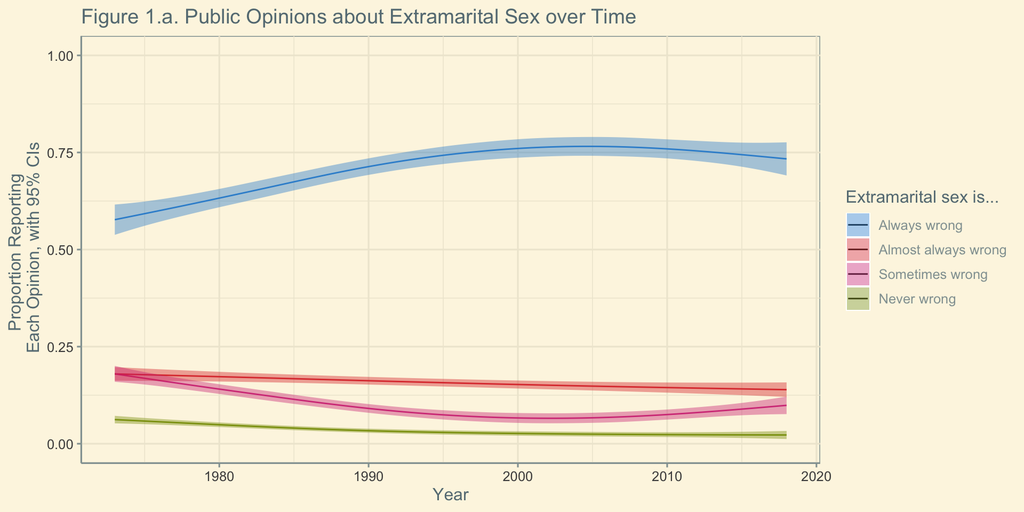

In Figure 1.a, we explore the change in opinion of extramarital sex over time. On the x-axis, this figure displays the year in which the surveys were conducted. On the y-axis, this figure displays the proportion of the sample that responded in each of the response categories.

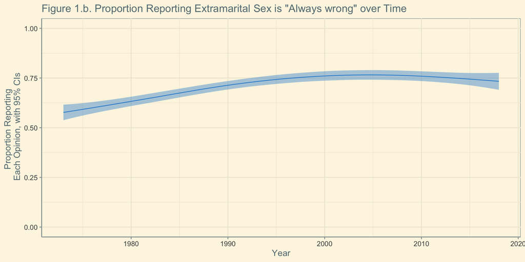

Figure 1.b shows just our selected response “Always wrong” over time. To investigate the change in the proportion of our sample that believe that extramarital sex is always wrong over time, we will conduct a hypothesis test to determine the difference in proportions between 1973 and 2018. To do so, we must first establish that the null and alternative hypotheses are as follows:

$H_{0}: p_{2018} - p_{1973} = 0$

$H_{a}: p_{2018} - p_{1973} \neq 0$

In the table below, we calculate the proportions for $p_{2018}$ and $p_{1973}$ as well as the upper and lower bounds of their 95% confidence intervals using the formula for the standard deviation of a proportion:

$\sigma_{\hat{p}} = \sqrt{\dfrac{\hat{p}(1 - \hat{p})}{n}}$

```
## # A tibble: 2 x 7
## # Groups:   year [2]
##    year     n respondents  prop     sd `CI Lower Bound` `CI Upper Bound`
##   <int> <int>       <int> <dbl>  <dbl>            <dbl>            <dbl>
## 1  1973  1028        1479 0.695 0.0120            0.672            0.719
## 2  2018  1159        1537 0.754 0.0110            0.733            0.776
```

We can now say that we are 95% confident that the true values of $p_{2018}$ and $P_{1973}$ are between 0.7325 and 0.07756 and 0.6716 and 0.7185, respectively. Because the 95% confidence intervals do not overlap, we say that these two proportions are statistically significantly different from one another, at the 5% significance level.

We can additionally calculate the standard deviation of a difference in proportions using the formula:

$\sigma_{\hat{p}_{1} - \hat{p}_{2}} = \sqrt{\dfrac{\hat{p}_{1}(1 - \hat{p}_{1})}{n_{1}} + \dfrac{\hat{p}_{2}(1 - \hat{p}_{2})}{n_{2}}}$

Having calculated the upper and lower bounds of the 95% confidence interval of the difference between $p_{2018}$ and $P_{1973}$, we can now say that we are 95% confident that the true value of $p_{2018} - p_{1973}$ is between 0.02149567 and 0.09650873. Because the null hypothesized value of 0 is not contained within our interval, we can reject the null hypothesized value of 0 for the difference in proportions of respondents reporting that extramarital sex is always wrong between 2018 and 1973.

**Research Question 2, How have U.S. adults’ opinions on extramarital sex differed by marital status since 1973?**

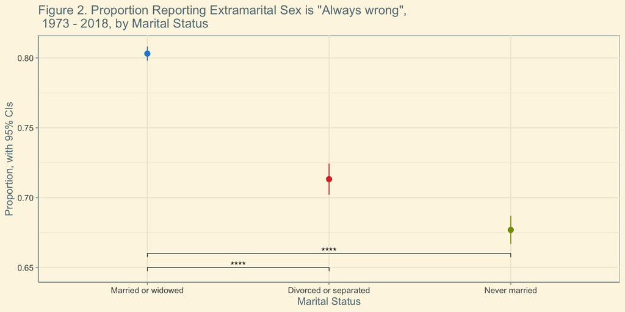

In Figure 2, we investigate the average proportion of respondents who feel that extramarital sex is “always wrong” by their marital status from 1973 to 2018. Figure 2 also shows 95% confidence intervals for each of the response categories and the significance levels of the differences in proportions between the married or widowed group and the divorced or separated and never married groups. Notice that the proportion of respondents who believe that extramarital sex is always wrong for each of these groups is rather different from one another. Also observe that the proportion of respondents who are married or widowed who believe that extramarital sex is much higher than that of the other two groups; that is to say that that among those who have ended a marriage or opted not to marry, a smaller proportion believe that extramarial sex is always wrong, as compared to those who are married or have been widowed.

$H_{0}: p_{Married\ or\ widowed} - p_{Divorced\ or\ separated} = 0$

$H_{a}: p_{Married\ or\ widowed} - p_{Divorced\ or\ separated} \neq 0$

and

$H_{0}: p_{Married\ or\ widowed} - p_{Never\ married} = 0$

$H_{a}: p_{Married\ or\ widowed} - p_{Never\ married} \neq 0$

We then calculate the standard deviation of a difference in proportions using the formula:

$\sigma_{\hat{p}_{1} - \hat{p}_{2}} = \sqrt{\dfrac{\hat{p}_{1}(1 - \hat{p}_{1})}{n_{1}} + \dfrac{\hat{p}_{2}(1 - \hat{p}_{2})}{n_{2}}}$

Having calculated the upper and lower bounds of the 95% confidence interval of the difference between $p_{Married\ or\ widowed}$ and $p_{Never\ married}$, we can now say that we are 95% confident that the true value of $p_{Married\ or\ widowed} - p_{Never\ married}$ is between 0.1126807 and 0.139616. Because the null hypothesized value of 0 is not contained within our interval, we can reject the null hypothesized value of 0 for the difference in proportions of respondents reporting that extramarital sex is always wrong between those that are married or widowed and those that have never married.

**Research Question 3, How have U.S. adults’ opinions on extramarital sex differed by their opinion of their family income in relation to that of the “average” American family sinc 1973?**

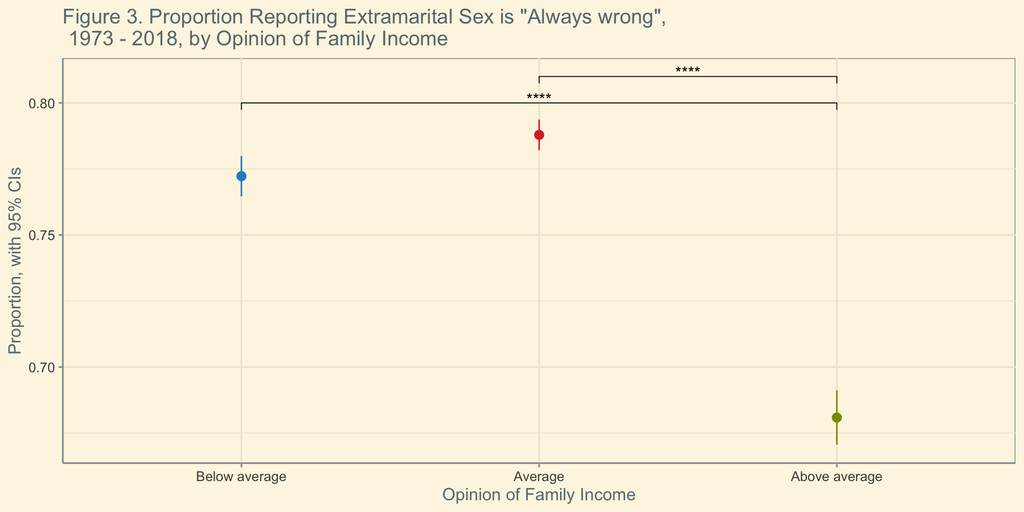

In Figure 3, we investigate the average proportion of respondents who feel that extramarital sex is “always wrong” by their opinion of their family income from 1973 to 2018. Figure 3 also shows 95% confidence intervals for each of the response categories and the significance levels of the differences in proportions between the average group and the average and below average groups. Notice that that the average and below average groups exhibit relatively similar proportions, as compared to that of the above average group. Also observe that in the proportion of respondents in the average and below average groups who believe that extramarital sex is always wrong much higher than that of the above average group; that is to say that among those who percieve their income to be less, a smaller proportion believe that extramarial sex is not always wrong, as compared to those who believe that their family income is above average.

$H_{0}: p_{Above\ avg.} - p_{Avg.} = 0$

$H_{a}: p_{Above\ avg.} - p_{Avg.} \neq 0$

and

$H_{0}: p_{Above\ avg.} - p_{Below\ avg.} = 0$

$H_{a}: p_{Above\ avg.} - p_{Below\ avg.} \neq 0$

We then calculate the standard deviation of a difference in proportions using the formula:

$\sigma_{\hat{p}_{1} - \hat{p}_{2}} = \sqrt{\dfrac{\hat{p}_{1}(1 - \hat{p}_{1})}{n_{1}} + \dfrac{\hat{p}_{2}(1 - \hat{p}_{2})}{n_{2}}}$

### Hackathon Report, Section 5: Conclusion

Over the course of our report, we explored how U.S. adults’ opinions on extramarital sex have changed over time from 1973 to 2018, the relationship between one’s marital status and such opinions, along with the relationship between one’s comparative view on their family income and such opinions. We hypothesized that the share of people who consider extramarital sex “always wrong” gradually declined between 1973 and 2018, that a higher share of married or widowed people consider extramarital sex “always wrong” compared to those divorced or separated or never married, and that a smaller share of people who believe their family income is above average consider extramarital sex “always wrong” compared to those who believe their family income is below average or average. Our findings for our first research question do not support our hypothesis that U.S. adults’ opinions on extramarital sex being “always wrong” have declined gradually over time from 1973 to 2018. As seen in Figure 1.a and Figure 1.b, the proportion of respondents that responded “always wrong” appears to be increasing over time, not decreasing as we initially predicted it would. We found that the difference in the proportions of respondents who considered extramarital sex “always wrong” in 1973 and in 2018 were statistically different at the 5% significance level through the hypothesis tests that we conducted. On the contrary, our findings for our second research question do in fact support our hypothesis that a higher share of people who are married or widowed consider extramarital sex “always wrong” compared to those divorced or separated or never married. As seen in Figure 2, the proportion of respondents married or widowed who believe that extramarital sex is “always wrong” is much higher than that of the other two groups; among those divorced or separated or never married, a smaller proportion belives that extramarial sex is “always wrong”. The hypothesis tests that we conducted comparing the proportion of those married or widowed to first those divorced or separated and then those never married, both deemed null hypothesis rejection, as we found that the differences in the proportions were statistically significant from one another at the 5% significance level, confirming our overall research question hypothesis. Lastly, our findings for our third research question support our hypothesis that a smaller share of respondents who believe that their family income is above average consider extramarital sex “always wrong” compared to those who believe that their family income is below average or average. As seen in Figure 3, the proportions of respondents who believe that their family income is below average or average are much higher than that of the respondents who believe that their family income is above average; in other words, among those who believe that their family income is above average, a smaller proportion believe that extramarital sex is “always wrong” - aligned exactly with our overall research question hypothesis. The hypothesis tests that we conducted comparing the proportion of those who think that their family income is above average to first those who think that theirs is average and then to those who think that theirs is below average, both deemed null hypothesis rejection, as we found that the differences in proportions were statistically significant from one another at the 5% significance level. Ultimately, while our results did not support our hypothesis for our first research question, they did in fact support our hypotheses for both our second and third research question.

We want to preface that the data we studied in this report was observational, from which we thus cannot draw causal conclusions, as the researchers conducting the survey did not actively control the value of any variable. Given that the study was observational, we therefore have to be conscious of confounding variables, keeping in mind that not all associations are causal and causation cannot be determined if a confounding variable is present. A possible confounding variable for our research question exploring the relationship between marital status and opinions on extramarital sex is respondents’ cheating history – whether or not one has ever cheated on their significant other, engaging in sexual relations with a person or persons other than with whom they were exclusive, and whether or not he/she has knowingly ever been cheated on by a significant other of theirs. One’s cheating history - either cheating, being cheating, both, or neither - could potentially offer a plausible explanation for an association between our explanatory variable, marital status, and our outcome variable, opinion on extramarital sex, as one’s marital status could very likely have been catalyzed by their experience(s) with disloyal relationships, responsible for why one may be divorced or separated for instance. Similar to the way that cheating history might be associated with marital status, it might be associated with opinion on extramarital sex, as it is possible that one’s prior experience with cheating could very likely have shaped their opinions on the extent to which they find extramarital sex wrong. Given the disparity we found in our report that there was a smaller share of respondents among those who have been in a failed marriage (divorced or separated) or opted not to marry (never married) believe that extramarital sex is “always wrong” compared to respondents who are married or widowed, maybe there is a true causal effect of marital status on extramarital sex opinions; however, maybe people who have cheated on their significant other before are less likely to think that extramarital sex is “always wrong” for instance, with cheating history being a potential confounding variable. Perhaps if we had compared respondents of the same cheating history, we wouldn’t have seen such great disparity between the married or widowed respondent category and the divorced or separated or never married respondent categories, as manifested in Figure 2.

Future areas of research that are of interest to us for furthering our knowledge on U.S. adults’ extramarital sex opinions revolve around exploration of other potential explanatory variables, including respondent gender, age, sexuality, political affiliation, frequency of sex during the last year, number of persons in household, and number of children. Such variables could provide us with supplemental insight that could possibly help us better understand the distribution of opinions on extramarital sex among U.S. adults. These insights could be heavily complemented with data establishing whether or not respondents have ever cheated on a significant other of theirs, engaging in sexual relations with a person or persons other than whom with whom they were were exclusive at the time, in addition to data establishing whether or not respondents have ever to their knowledge been cheated on by a significant other of theirs, as both would likely influence one’s opinion on extramarital sex to a substantial degree.

### Hackathon Report, Section 6: Appendix

These graphs go beyond the scope of our research questions and this report, however, we wanted to include them because they suggest additional, meaningful insights, and the opportunity for continued research.

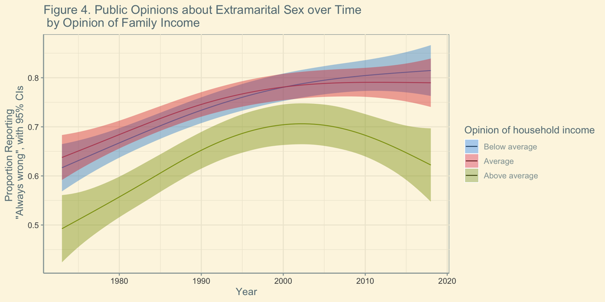

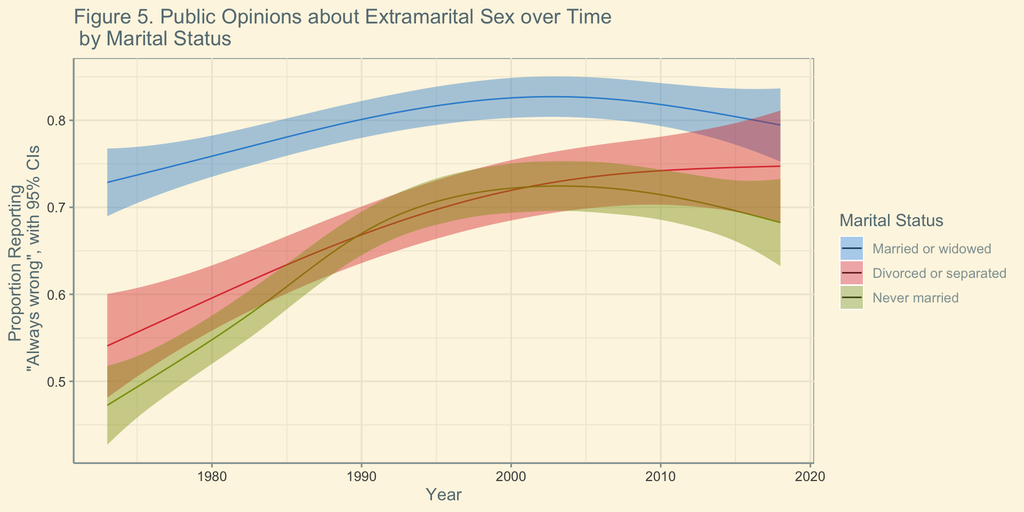